# Exercise Performance Prediction

Nel Antuña

18/12/2020

# Introduction

The purpose of this project will be to predict the way in which certain people perform some training exercises by analysing information gathered from body devices.

Due to computer limitations, the type of prediction made will be pretty simple so that my laptop can run it.

# Initial options

For this project we will mostly work with the following packages:

- Tidyverse package -> for data manipulation
- Caret package -> for machine learning operations

In addition, we will set seeds so that results can be replicable.

```r
library(tidyverse)
library(caret)
set.seed(255)
```

# Data exploration

## Data source

Data has been obtained from this source: http://web.archive.org/web/20161224072740/http:/groupware.les.inf.puc-rio.br/har

```r
setwd("C:/Users/Nel/Documents/R files/college_major_analysis/")
download.file("https://d396qusza40orc.cloudfront.net/predmachlearn/pml-training.csv", destfile = "training.csv")
download.file("https://d396qusza40orc.cloudfront.net/predmachlearn/pml-testing.csv", destfile = "testing.csv")
dataset <- read.csv("./training.csv")
```

## Data exploration

```
##
## character   integer   numeric
##        37        35        88
```

## Covariate selection

We will examine the dataset and select those variables relevant for the analysis

### Non-relevant variables

There are a series of variables that have no relation to the activity performance:

- Variable ‘X’ -> only gives the row number
- Time variables -> not required for the prediction
- User name -> not needed
- New and num window -> not relevant

```r
time_var <- colnames(select(dataset, contains("time")))
non_relevant <- c("X",time_var,"user_name","new_window","num_window")
```

### Detecting variables with high amount of NAs

We label those variables with over 90% of missing values

```r
nas <- rep(FALSE, ncol(dataset))
for (i in 3:ncol(dataset)) {
 t <- tapply(dataset[,i],dataset$user_name, function(x) mean(is.na(x)))
 if (mean(t) > 0.90) {nas[i] <- TRUE}
}
cols_with_nas <- colnames(dataset)[nas]
```

### Detecting variables with high amount of incomplete data

We label those variables with over 90% of incomplete data

```r
nulls <- apply(dataset, 2, function(x) mean(x == ""))>0.90
cols_with_nulls <- colnames(dataset)[nulls]
cols_with_nulls <- cols_with_nulls[!is.na(cols_with_nulls)]
```

## Final dataset

```r
non_var <- c(non_relevant,cols_with_nas,cols_with_nulls)
dataset_new <- select(dataset, -non_var)
dims_new <- dim(dataset_new)
```

The new dataset contains same number of observations (19622) but only 53 variables

### Outcome

Outcome is Classe variable: category variable with the following options

```
##
##    A    B    C    D    E
## 5580 3797 3422 3216 3607
```

### Predictors

Below is displayed the number of predictors finally consider and their class:

```
##
## integer numeric
##      25      27
```

A high-level exploration of the data shows that predictors don’t seem to adhere to the normal distributions and correlation among them might lead to problems. Below an example with 5 of the variables:

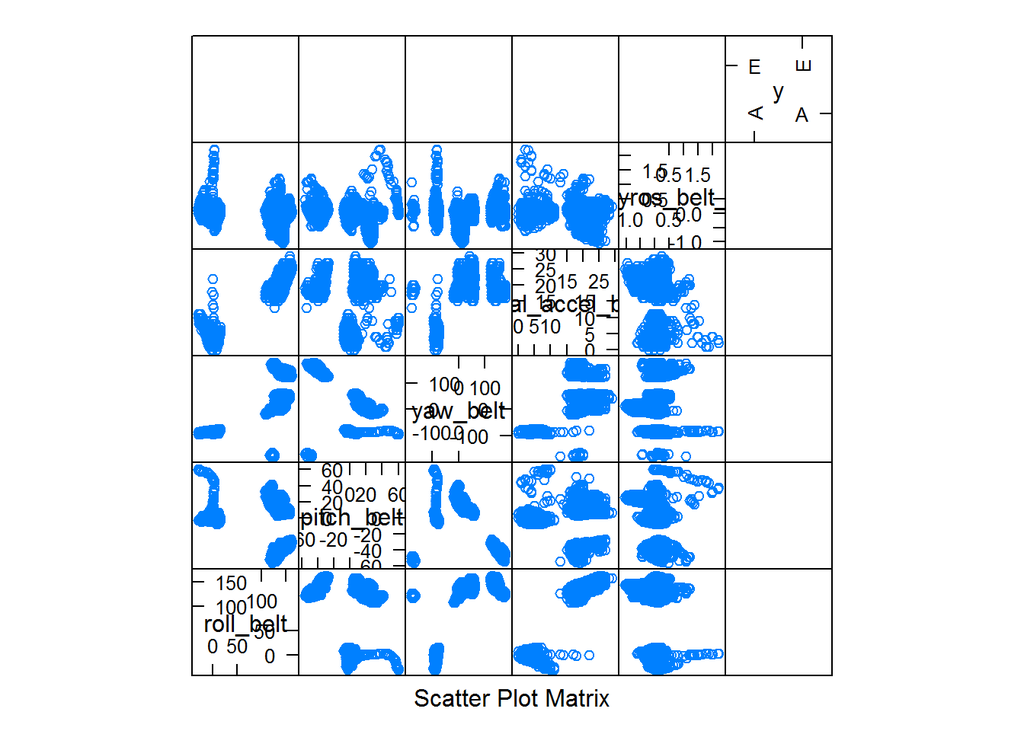

# Prediction analysis

## Setting up training and testing data sets

We start by creating a partition of the data for training and testing datasets

```r
inTrain <- createDataPartition(y = dataset_new$classe, p=0.8, list=FALSE)
training <- dataset_new[inTrain,]
testing <- dataset_new[-inTrain,]
```

## Training a model

We will use the training data set to produce our models. Characteristics:

```r
fit_ctrees <- train(classe~., data = training, method = c("ctree", "PCA", "BoxCox"))
```

## Accuracy

```r
pred_ctrees_test <- predict(fit_ctrees, testing)

acc_ctrees <- (sum(pred_ctrees_test==testing$classe)/length(pred_ctrees_test))
```

When compare the prediciton of the testing values with the actual values, we see that the accuracy of the model is of 0.8980372

# Prediciton

The initial dataset included 20 observations with ououtcome assign. We will predict the outcome of this data:

First, we need to prepare the data:

```r
test_data <- read.csv("./testing.csv")
#non_var object contained those variables that are not useful or have missing/incomplete values
test_data_new <- select(test_data, -non_var)
```

We run prediction on the data and these are the results:

```
##  [1] B A A A A B D B A A C C B A E E A B B B
## Levels: A B C D E
```